# HW2_SupervisedLearning_01

## HW#2 Supervised Learning I

In this assignment, you are going to practice supervised learning ML modelings.

**DUE: 10/12/2020 Thursday 11:59 PM.**

### Problem #1 Linear Regression (20 pts)

Data: Bike Sharing Dataset

#### Data Set

Bike-sharing rental process is highly correlated to the environmental and seasonal settings. For instance, weather conditions, precipitation, day of week, season, hour of the day, etc. can affect the rental behaviors. The core data set is related to  
the two-year historical log corresponding to years 2011 and 2012 from Capital Bikeshare system, Washington D.C., USA which is publicly available in http://capitalbikeshare.com/system-data. We aggregated the data on two hourly and daily basis and then extracted and added the corresponding weather and seasonal information. Weather information are extracted from http://www.freemeteo.com.

#### Files

- hour.csv : bike sharing counts aggregated on hourly basis. Records: 17379 hours
- day.csv - bike sharing counts aggregated on daily basis. Records: 731 days

#### Dataset Characteristics:

Both hour.csv and day.csv have the following fields, except hr which is not available in day.csv

```
- instant: record index
- dteday : date
- season : season (1:springer, 2:summer, 3:fall, 4:winter)
- yr : year (0: 2011, 1:2012)
- mnth : month ( 1 to 12)
- hr : hour (0 to 23)
- holiday : weather day is holiday or not (extracted from http://dchr.dc.gov/page/holiday-schedule)
- weekday : day of the week
- workingday : if day is neither weekend nor holiday is 1, otherwise is 0.
- weathersit :
    - 1: Clear, Few clouds, Partly cloudy, Partly cloudy
    - 2: Mist + Cloudy, Mist + Broken clouds, Mist + Few clouds, Mist
    - 3: Light Snow, Light Rain + Thunderstorm + Scattered clouds, Light Rain + Scattered clouds
    - 4: Heavy Rain + Ice Pallets + Thunderstorm + Mist, Snow + Fog
- temp : Normalized temperature in Celsius. The values are divided to 41 (max)
- atemp: Normalized feeling temperature in Celsius. The values are divided to 50 (max)
- hum: Normalized humidity. The values are divided to 100 (max)
- windspeed: Normalized wind speed. The values are divided to 67 (max)
- casual: count of casual users
- registered: count of registered users
- cnt: count of total rental bikes including both casual and registered
```

#### Task

- Predict the count of total rental bikes including both casual and registered.
- Test Set: Daily Basis - August, Hourly Basis - Summer Season (June, July, and August from 10 AM to 2 PM)

a) (2 pts) Split the datasets into train and test sets. (do for both)

```python
import pandas as pd
import numpy as np
import seaborn as sns
import matplotlib.pyplot as plt
from numpy import ndarray
from sklearn.linear_model import LinearRegression
```

```python
day = pd.read_csv('day.csv', index_col=0)
hour = pd.read_csv('hour.csv', index_col=0)

print("Separating day dataset into train and test set with month of August being the test.")
day_train = day.loc[day['mnth'] != 8]
day_test = day.loc[day['mnth'] == 8]

assert (day_train.shape[0] + day_test.shape[0]) == day.shape[0]  # Make sure we capture all the data

print("Separating hour dataset into train & test set with June, July, and August from 10 AM to 2 PM being " \
      "the test.")
hour_test = hour.loc[((hour['mnth'] >= 6) & (hour['mnth'] <= 8) & (hour['hr'] >= 10) & (hour['hr'] <= 14))]
hour_train = hour.loc[
    (((hour['mnth'] < 6) | (hour['mnth'] > 8)) |
    (((hour['mnth'] >= 6) & (hour['mnth'] <= 8) & (hour['hr'] < 10) | (hour['hr'] > 14))))
]

assert (hour_train.shape[0] + hour_test.shape[0]) == hour.shape[0] # Make sure we capture all the data
```

```
Separating day dataset into train and test set with month of August being the test.
Separating hour dataset into train & test set with June, July, and August from 10 AM to 2 PM being the test.
```

b) (2 pts) Before you do anything with the train datasets, which features can be deleted? Explain why. (do for both)

## Answer

> The columns `dteday` and `yr` can be deleted because they are cyclical and will not add any additional contextual data to training and testing sets.
> - Since the necessary descriptors from the day have already been extracted (e.g. `temp`, `atemp`, `hum`, `workingday` and others), the actual date is not necessary. Moreover, a simple date will likely not influence a decision to rent a bike.
> - The specific year will likely not have any influence on whether or not a person rents a bike. Concretely, a person is not likely to decide to rent a bike simply because it is 2012. Hence, this can be removed.

> The column `mnth` can be removed because it has already been encoded as the `season` column.

> Maybe: `holiday`, `weekday` because they are encapsulated in other columns, but I will leave them in for further correlative testing.

```python
to_drop = ['dteday', 'yr', 'mnth']
day_train = day_train.drop(labels=to_drop, axis=1)
day_test = day_test.drop(labels=to_drop, axis=1)

hour_train = hour_train.drop(labels=to_drop, axis=1)
hour_test = hour_test.drop(labels=to_drop, axis=1)

day_test
```

| instant | season | holiday | weekday | workingday | weathersit | temp | atemp | hum | windspeed | casual | registered | cnt |
| --- | --- | --- | --- | --- | --- | --- | --- | --- | --- | --- | --- | --- |
| 213 | 3 | 0 | 1 | 1 | 1 | 0.771667 | 0.703292 | 0.550833 | 0.156717 | 729 | 3537 | 4266 |
| 214 | 3 | 0 | 2 | 1 | 1 | 0.783333 | 0.707071 | 0.491250 | 0.205850 | 801 | 4044 | 4845 |
| 215 | 3 | 0 | 3 | 1 | 2 | 0.731667 | 0.679937 | 0.657500 | 0.135583 | 467 | 3107 | 3574 |
| 216 | 3 | 0 | 4 | 1 | 2 | 0.710000 | 0.664788 | 0.757500 | 0.197150 | 799 | 3777 | 4576 |
| 217 | 3 | 0 | 5 | 1 | 1 | 0.710833 | 0.656567 | 0.630833 | 0.184696 | 1023 | 3843 | 4866 |
| ... | ... | ... | ... | ... | ... | ... | ... | ... | ... | ... | ... | ... |
| 605 | 3 | 0 | 1 | 1 | 1 | 0.703333 | 0.654688 | 0.730417 | 0.128733 | 989 | 5928 | 6917 |
| 606 | 3 | 0 | 2 | 1 | 1 | 0.728333 | 0.666050 | 0.620000 | 0.190925 | 935 | 6105 | 7040 |
| 607 | 3 | 0 | 3 | 1 | 1 | 0.685000 | 0.635733 | 0.552083 | 0.112562 | 1177 | 6520 | 7697 |
| 608 | 3 | 0 | 4 | 1 | 1 | 0.706667 | 0.652779 | 0.590417 | 0.077117 | 1172 | 6541 | 7713 |
| 609 | 3 | 0 | 5 | 1 | 1 | 0.764167 | 0.689400 | 0.587500 | 0.168533 | 1433 | 5917 | 7350 |

62 rows × 12 columns

c) (2 pts) Make `weathersit` and `weekday` one-hot vectors. (do for both)

- Do you think this process is necessary? Do you find other features that are necessary to do this? Explain why. If you find any features that are needed to be tranformed into one-hot vectors, please do.
- **Do not** do on the test sets here as well as step d).

## Answer

> Yes, the one-hot encoding process is necessary because, otherwise, the model may assume that one category is more statistically significant than the other simply by its number. Concretely, this means that the model may weight something like Thursday (4) more Monday (1) (e.g. the mean would be 1 + 4 / 2 = 2.5, which weighs more heavily toward Thursday).
> - The other categories that are necessary to one-hot encode are `season` and `hr` (for the hourly data).

```python
### Code Starts Here ###

encoding = dict(
    weathersit=dict(is_clear=1, is_cloudy=2, is_rainy=3),
    weekday=dict(sun=0, mon=1, tues=2, wed=3, thur=4, fri=5),
    season=dict(spring=1, summer=2, fall=3),
    hr=dict(morning=[6,7,8,9,10,11], afternoon=[12,13,14,15,16,17,18,19,20])
)


def one_hot(col: str, mapping: dict, df: pd.DataFrame) -> pd.DataFrame:
    """ One hot encodes a column "col" in a pandas DataFrame using the categories passed like

        {
            "encode_col": "current_value"
        }

        The old categorical column will also be dropped from the data frame
    """

    df_copy = df.copy()
    for k, v in mapping.items():
        if isinstance(mapping[k], list):
            df[k] = df.apply(lambda x: int(x[col] in mapping[k]), axis=1)
        else:
            df[k] = df.apply(lambda x: int(x[col] == mapping[k]), axis=1)
    return df.drop(col, axis=1)


for col, mapping in encoding.items():
    print(f"One hot encoding {col}")
    if col in day_train.columns:
        day_train = one_hot(col, mapping, day_train)
    if col in hour_train.columns:
        hour_train = one_hot(col, mapping, hour_train)

day_train
```

```
One hot encoding weathersit
One hot encoding weekday
One hot encoding season
One hot encoding hr
```

| instant | holiday | workingday | temp | atemp | hum | windspeed | casual | registered | cnt | is_clear | ... | is_rainy | sun | mon | tues | wed | thur | fri | spring | summer | fall |
| --- | --- | --- | --- | --- | --- | --- | --- | --- | --- | --- | --- | --- | --- | --- | --- | --- | --- | --- | --- | --- | --- |
| 1 | 0 | 0 | 0.344167 | 0.363625 | 0.805833 | 0.160446 | 331 | 654 | 985 | 0 | ... | 0 | 0 | 0 | 0 | 0 | 0 | 0 | 1 | 0 | 0 |
| 2 | 0 | 0 | 0.363478 | 0.353739 | 0.696087 | 0.248539 | 131 | 670 | 801 | 0 | ... | 0 | 1 | 0 | 0 | 0 | 0 | 0 | 1 | 0 | 0 |
| 3 | 0 | 1 | 0.196364 | 0.189405 | 0.437273 | 0.248309 | 120 | 1229 | 1349 | 1 | ... | 0 | 0 | 1 | 0 | 0 | 0 | 0 | 1 | 0 | 0 |
| 4 | 0 | 1 | 0.200000 | 0.212122 | 0.590435 | 0.160296 | 108 | 1454 | 1562 | 1 | ... | 0 | 0 | 0 | 1 | 0 | 0 | 0 | 1 | 0 | 0 |
| 5 | 0 | 1 | 0.226957 | 0.229270 | 0.436957 | 0.186900 | 82 | 1518 | 1600 | 1 | ... | 0 | 0 | 0 | 0 | 1 | 0 | 0 | 1 | 0 | 0 |
| ... | ... | ... | ... | ... | ... | ... | ... | ... | ... | ... | ... | ... | ... | ... | ... | ... | ... | ... | ... | ... | ... |
| 727 | 0 | 1 | 0.254167 | 0.226642 | 0.652917 | 0.350133 | 247 | 1867 | 2114 | 0 | ... | 0 | 0 | 0 | 0 | 0 | 1 | 0 | 1 | 0 | 0 |
| 728 | 0 | 1 | 0.253333 | 0.255046 | 0.590000 | 0.155471 | 644 | 2451 | 3095 | 0 | ... | 0 | 0 | 0 | 0 | 0 | 0 | 1 | 1 | 0 | 0 |
| 729 | 0 | 0 | 0.253333 | 0.242400 | 0.752917 | 0.124383 | 159 | 1182 | 1341 | 0 | ... | 0 | 0 | 0 | 0 | 0 | 0 | 0 | 1 | 0 | 0 |
| 730 | 0 | 0 | 0.255833 | 0.231700 | 0.483333 | 0.350754 | 364 | 1432 | 1796 | 1 | ... | 0 | 1 | 0 | 0 | 0 | 0 | 0 | 1 | 0 | 0 |
| 731 | 0 | 1 | 0.215833 | 0.223487 | 0.577500 | 0.154846 | 439 | 2290 | 2729 | 0 | ... | 0 | 0 | 1 | 0 | 0 | 0 | 0 | 1 | 0 | 0 |

669 rows × 21 columns

d) (2 pts) Using the train sets, find the correlation between coorelations between features and target variable.

- Did you find other features that can be deleted? Explain why.

## Answer

### Both Data Sets

> There are a few more columns that can be deleted from both datasets: `temp`, `workingday`, `weekday`, and `holiday`.
- `workingday`, `holiday`, and `weekday` are not strongly correlated with the `cnt` in either the `hour_train` or `day_train` testing sets, so they can be deleted.
- `temp` can be deleted because `atemp` and `temp` are describing essentially the same phenomena (as evidenced by the near perfect correlation between the variables). However, `atemp` provides a slightly better correlation with the `cnt` variable, so I am choosing to keep `atemp` over `temp`.

### Hour Train

> The `weathersit` variable can also be deteled because it does not have a good correlation with the `cnt` target variable.

### Day Train

> For the `day_train` data set, the `hum` variable can be deleted for the same reason.

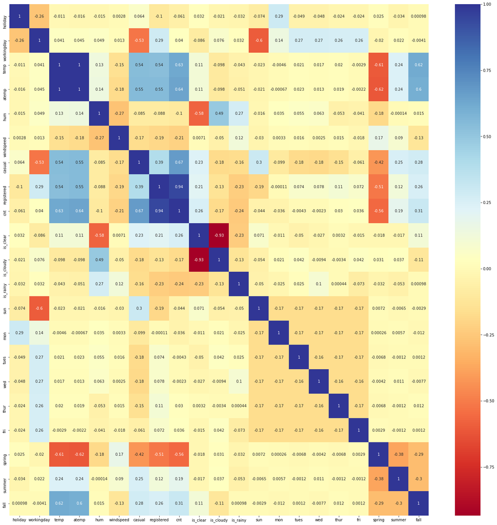

```python
### Code Starts Here ###
day_corr = day_train.corr()
plt.figure(figsize=(25,25))
sns.heatmap(day_corr, annot=True, cmap="RdYlBu")

# Keep: atemp, spring, fall, is_rainy, is_clear,
```

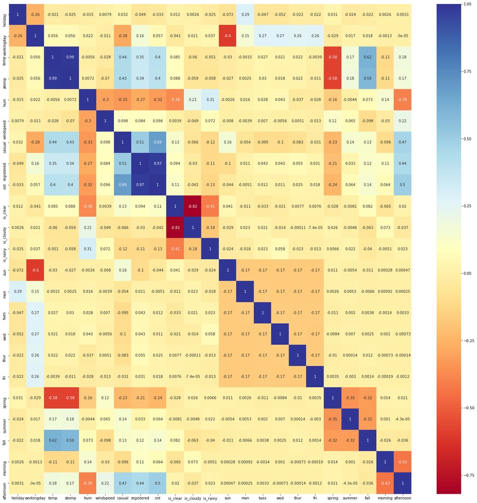

```python
hour_corr = hour_train.corr()
plt.figure(figsize=(25,25))
sns.heatmap(hour_corr, annot=True, cmap="RdYlBu")

# Keep atemp, hum, morning, afternoon, evening, spring, summer, fall
```

e) (1 pts) Do you think you need to do cross-validation? What is the advantage and disadvantage of doing it?

### Answer Here

Yes, I think cross-validation is necessary. Cross-validation is necessary because it helps to ensure that the model is not picking up on noise; rather it is reflecting the actual trends in the data set.

- The advantage is that we get a real-time capture of how well our model performs on "new" data.
- The downside is that it removes some of the training data and it may result is less general model.

f) (7 pts) Using `LinearRegression` from `sklearn` and `polyfit` from `numpy`, train two models each by having all features and 5 features based on step a) thru d). You might have to train polynomial model multiple times and you may go back do futher feature engineerings. **If you do, please show all work. Do not erase any work.** (do for both)

```python
### Code Starts Here ###
from sklearn.preprocessing import PolynomialFeatures
from sklearn.linear_model import LinearRegression
from sklearn.pipeline import Pipeline

def polyfit(X: pd.DataFrame, y: pd.DataFrame):
    """ Uses numpy's polyfit to train the model """
    model = []
    y = np.array(y)
    y = y.reshape(y.shape[0])
    for label, col in X.iteritems():
        x = np.array(col)
        m = np.polyfit(x, y, 1)
        model.append(m)
    return np.array(model)

def sklinear(X: pd.DataFrame, y: pd.DataFrame):
    """ Uses sklearn LinearRegression to train the model """
    polyreg = Pipeline([('poly', PolynomialFeatures(degree=1)), ('model', LinearRegression())])
    return polyreg.fit(X, y)

hour_features = ['atemp', 'hum', 'is_clear', 'afternoon', 'spring']
day_features = ['atemp', 'spring', 'fall', 'is_rainy', 'is_clear']
not_features = ['cnt', 'casual', 'registered']

### Day
X_day = day_train.loc[:, day_features]
X_all_day = day_train.loc[:, [col for col in day_train.columns if col not in not_features]]
y_day = day_train.loc[:, ['cnt']]

skday = sklinear(X_day, y_day)
all_skday = sklinear(X_all_day, y_day)

polyday = polyfit(X_day, y_day)
all_polyday = polyfit(X_all_day, y_day)


### Hour
X_hour = hour_train.loc[:, hour_features]
X_all_hour = hour_train.loc[:, [col for col in hour_train.columns if col not in not_features]]
y_hour = hour_train.loc[:, ['cnt']]

skhour = sklinear(X_hour, y_hour)
all_skhour = sklinear(X_all_hour, y_hour)

polyhour = polyfit(X_hour, y_hour)
all_polyhour = polyfit(X_all_hour, y_hour)
```

g) (2 pts) Report value of coefficent ${\bf w}$, **RMSE**, and **$R^2$** of all models. Which model is the best? Explain why. (asnwer for both data sets)

```python
### Code Starts Here ###
from sklearn import metrics

def polypredict(model, X: pd.DataFrame) -> ndarray:
    """ Gets the predictions for the model """
    n = X.shape[0]
    stack = None
    for idx, m in enumerate(model):
        data = np.array(X[X.columns[idx]])
        predict = np.poly1d(m)(data).reshape(n, 1)
        if stack is None:
            stack = predict
        else:
            stack = np.hstack((stack,predict))
    return np.mean(stack, axis=1)


def polyreport(name: str, model: ndarray, X: pd.DataFrame, y: pd.DataFrame) -> None:
    """ Reports the coefficients, Root Mean Squared Error, and the R^2 for the polyfit model """
    intercept = np.mean(model, axis=0)[1]
    coef = np.array([*np.delete(model, 1, 1).reshape(model.shape[0]), intercept])
    y_pred = polypredict(model, X)
    report(name, coef, y_pred, y)


def skreport(name: str, model: LinearRegression, X: pd.DataFrame, y: pd.DataFrame) -> None:
    """ Reports the coefficients, Root Mean Squared Error, and the R^2 for Sklearn's LinearRegression model """
    coef = model.named_steps.model.coef_
    y_pred = model.predict(X)
    report(name, coef, y_pred, y)


def report(name: str, coef: ndarray, y_pred: ndarray, y: ndarray):
    print(f"================================= {name.upper()} Results ============================================")
    print(f"Coefficients are as follows: {coef}")
    rsme = metrics.mean_squared_error(y, y_pred)
    r_2 = metrics.r2_score(y, y_pred)
    print(f"The RSME for the model is {rsme} and the R^2 score is {r_2}")
    print("================================= END Results ============================================\n\n")

model_name = ("day", "all_day", "hour", "all_hour")
skreport("skday", skday, X_day, y_day)
polyreport("polyday", polyday, X_day, y_day)

skreport("all skday", all_skday, X_all_day, y_day)
polyreport("all polyday", all_polyday, X_all_day, y_day)

skreport("skhour", skhour, X_hour, y_hour)
polyreport("polyhour", polyhour, X_hour, y_hour)

skreport("all skhour", all_skhour, X_all_hour, y_hour)
polyreport("all skhour", all_polyhour, X_all_hour, y_hour)
```

```
================================= SKDAY Results ============================================
Coefficients are as follows: [[    0.          5833.96304    -1295.21277396  -432.29026376
  -2095.17359561   645.3305205 ]]
The RSME for the model is 1752541.4095851113 and the R^2 score is 0.5332820355337595
================================= END Results ============================================


================================= POLYDAY Results ============================================
Coefficients are as follows: [ 7752.88503362 -2457.62355086  1524.73625362 -2677.6031746
  1025.81792886  3650.32588308]
The RSME for the model is 2612566.8290414354 and the R^2 score is 0.30424932283289197
================================= END Results ============================================


================================= ALL SKDAY Results ============================================
Coefficients are as follows: [[ 0.00000000e+00  3.36542417e+15  3.36542417e+15 -7.91500000e+02
   7.84581250e+03 -2.54181250e+03 -2.36317188e+03 -5.06062886e+15
  -5.06062886e+15 -5.06062886e+15 -4.02875000e+02 -3.36542417e+15
  -3.36542417e+15 -3.36542417e+15 -3.36542417e+15 -3.36542417e+15
  -1.47550000e+03 -5.80750000e+02 -9.56375000e+02]]
The RSME for the model is 1607301.826606876 and the R^2 score is 0.5719606779651386
================================= END Results ============================================


================================= ALL POLYDAY Results ============================================
Coefficients are as follows: [ -683.28703704   167.68721442  6823.55133056  7752.88503362
 -1342.57061973 -5209.7655468   1025.81792886  -704.57110037
 -2677.6031746   -242.23988898  -197.73374782   -24.1034293
   -12.67232192   163.78828168   201.99231616 -2457.62355086
   821.41193411  1524.73625362  4108.12896184]
The RSME for the model is 3192418.1567953094 and the R^2 score is 0.1498295585396181
================================= END Results ============================================


================================= SKHOUR Results ============================================
Coefficients are as follows: [[   0.          293.21584986 -174.77993548    3.39733262  145.36259811
   -50.6699897 ]]
The RSME for the model is 20610.9909974654 and the R^2 score is 0.3848643864624798
================================= END Results ============================================

```

[output cut: 12 more lines]

```
  -2.64690264e+13 -2.64690264e+13 -2.64690264e+13 -2.64690264e+13
  -5.75371094e+01 -3.27841797e+01 -4.79355469e+01  1.50531250e+02
   2.03356445e+02]]
The RSME for the model is 16794.80526349299 and the R^2 score is 0.4987585584180604
================================= END Results ============================================


================================= ALL SKHOUR Results ============================================
Coefficients are as follows: [ -35.08228903   22.43189084  399.35279327  441.85831506 -300.63213692
  143.76318554   43.31330134  -17.5842874   -83.21720142  -23.15597984
   -2.68221331    6.24377098    5.56226201   12.86783765    9.63102456
  -99.77247405   26.68181766   59.32073056   27.50577075  189.14928895
  168.39390236]
The RSME for the model is 30972.913246948083 and the R^2 score is 0.07561252170995814
================================= END Results ============================================
```

## Best models

- The best model for the `day` dataset is the `ALL SKDAY` model because it has the highest R^2 value (i.e. it explains most of the data set)
- The best model for the `hour` dataset is the `ALL SKHOUR` model for the same reason above.

h) (2 pts) Using the best model out of 4 models, evaluate the model using the test sets. Can you use a model from daily data to hourly test set? Explain why or why not.

## Answer

> You cannot use a model from the daily data to test the hourly data because:
> 1. They provide different data,
> 2. The models have different features, and
> 3. The data is geared toward a different measurement (one for the entire day, and one for the hour).

> These are not very well done models - they score quite poorly when presented with new data.

```python
### Code Starts Here ###
best_day = all_skday
best_hour = all_skhour


for col, mapping in encoding.items():
    if col in day_test.columns:
        day_test = one_hot(col, mapping, day_test)
    if col in hour_test.columns:
        hour_test = one_hot(col, mapping, hour_test)

not_features = ['cnt', 'casual', 'registered']
xday = day_test.loc[:, [col for col in day_test.columns if col not in not_features]]
yday = day_test.loc[:, ['cnt']]

xhour = hour_test.loc[:, [col for col in hour_test.columns if col not in not_features]]
yhour = hour_test.loc[:, ['cnt']]

print(f"Best model for day scores: {best_day.score(xday, yday)}")
print(f"Best model for hour scores: {best_hour.score(xhour, yhour)}")
```

```
Best model for day scores: 0.011320634607592361
Best model for hour scores: -0.7910931107503225
```

### Problem 2 - Non-probabilitistc Classifications (Lecture 3 and 4) (32 pts)

Dataset: Iris Data - find here: https://archive.ics.uci.edu/ml/datasets/iris

```python
# Loading the IRIS code (like in the demonstration HTML)
from sklearn import datasets
iris = datasets.load_iris()
iris.target
```

```
array([0, 0, 0, 0, 0, 0, 0, 0, 0, 0, 0, 0, 0, 0, 0, 0, 0, 0, 0, 0, 0, 0,
       0, 0, 0, 0, 0, 0, 0, 0, 0, 0, 0, 0, 0, 0, 0, 0, 0, 0, 0, 0, 0, 0,
       0, 0, 0, 0, 0, 0, 1, 1, 1, 1, 1, 1, 1, 1, 1, 1, 1, 1, 1, 1, 1, 1,
       1, 1, 1, 1, 1, 1, 1, 1, 1, 1, 1, 1, 1, 1, 1, 1, 1, 1, 1, 1, 1, 1,
       1, 1, 1, 1, 1, 1, 1, 1, 1, 1, 1, 1, 2, 2, 2, 2, 2, 2, 2, 2, 2, 2,
       2, 2, 2, 2, 2, 2, 2, 2, 2, 2, 2, 2, 2, 2, 2, 2, 2, 2, 2, 2, 2, 2,
       2, 2, 2, 2, 2, 2, 2, 2, 2, 2, 2, 2, 2, 2, 2, 2, 2, 2])
```

a) (8 pts) Implement KNN algorithm, call it `myKNN`. You are welcome to use `numpy` for implementation but nothing else.

```python
### Code Starts Here ###
import math
from collections.abc import Iterable

class myKNN:
    """ Implements the k-nearest neighbor algorithm """

    def __init__(self, k: int, p: int):
        """ Initializes the class with the number of neighbors and the p """
        if k == 0 or p == 0:
            raise ValueError("K must be above 0 and p must be either 1 or 2")
        self.k = k
        self.p = p
        self.data = None
        self.labels = None

    def fit(self, X: ndarray, y: ndarray) -> None:
        """ Initializes the data """
        data = self._create_nparray(X)
        labels = self._create_nparray(y)
        if data.shape[0] != labels.shape[0]:
            raise ValueError("Data and targets must have same number of rows")

        ex1 = self._create_nparray(data[0])
        if len(ex1.shape) != 1:
            raise ValueError("Data examples should only be one dimensional")

        self.data = data
        self.labels = labels

    def score(self, X: ndarray, y: ndarray) -> float:
        """ Scores how well the KNN predicts """
        correct = 0.0
        for idx, x in enumerate(X):
            label = self.predict(x)
            correct += int(label == y[idx])
        return correct / len(y)

    def predict(self, tests: ndarray) -> ndarray:
        """ Predicts the target value based on the initialized data """
        if self.data is None or tests is None or len(tests) == 0:
            raise ValueError("Not sufficient data to predict")

        if len(tests.shape) == 1:
            return self._predict(tests)

        classes = []
        for t in tests:
            classes.append(self._predict(t))
        return np.array(classes)

    def _predict(self, test: ndarray) -> ndarray:
        """ Makes a prediction for a single test case """
        test = self._create_nparray(test)
        neighbors = self._k_neighbors(test)  # Get nearest neighbors
        labels = [self.labels[i] for i, v in neighbors]  # Get the labels for the neighbors
        return self._mode(labels)  # Get the most common class

    def _k_neighbors(self, target: ndarray) -> list:
        """ Gets the k nearest neighbors from the test point """
        neighbors = list()
        for idx, d in enumerate(self.data):
            d = self._create_nparray(d)
            if target.shape != d.shape:
                raise ValueError(f"Shapes of test data {target} does not match initialized data {d}")

            dist = self._distance(d, target)
            neighbors.append((idx, dist))
        return sorted(neighbors, key=lambda x: x[1])[:self.k]

    def _distance(self, x: ndarray, y: ndarray):
        """ Calculates the distnace between two points """
        total = np.power(abs(x - y), self.p)
        if isinstance(total, ndarray):
            total = sum(total)
        return np.power(total, 1/self.p)

    @staticmethod
    def _mode(labels: list):
        """ Returns the mode given a list of items
            Fast one-line solution from: https://stackoverflow.com/questions/10797819/finding-the-mode-of-a-list
        """
        return max(set(labels), key=labels.count)

    @staticmethod
    def _create_nparray(x) -> ndarray:
        """ Creates a numpy array from a piece of data """
        if not isinstance(x, np.ndarray):
            if not isinstance(x, Iterable):
                x = np.array([x])
            else:
                x = np.array(x)
        return x
```

b)(4 pts) Without splitting the dataset, classify the names using `myKNN` from $k=1$ to $25$. Then report the accuracy of `myKNN` for each $k$ value. You are free to extend the range of $k$ values up to $50$.

```python
### Code Starts Here ###
my_x = []
my_y = []

for i in range(1, 51):
    knn = myKNN(k=i, p=2)
    knn.fit(iris.data, iris.target)
    score = knn.score(iris.data, iris.target)
    my_x.append(i)
    my_y.append(score)
    print(f"myKNN scored {score * 100}% for a K of {i}")
```

```
myKNN scored 100.0% for a K of 1
myKNN scored 98.0% for a K of 2
myKNN scored 96.0% for a K of 3
myKNN scored 96.0% for a K of 4
myKNN scored 96.66666666666667% for a K of 5
myKNN scored 97.33333333333334% for a K of 6
myKNN scored 97.33333333333334% for a K of 7
myKNN scored 98.0% for a K of 8
myKNN scored 98.0% for a K of 9
myKNN scored 98.0% for a K of 10
myKNN scored 97.33333333333334% for a K of 11
myKNN scored 98.0% for a K of 12
myKNN scored 98.0% for a K of 13
myKNN scored 98.0% for a K of 14
myKNN scored 98.66666666666667% for a K of 15
myKNN scored 98.66666666666667% for a K of 16
myKNN scored 98.0% for a K of 17
myKNN scored 97.33333333333334% for a K of 18
myKNN scored 98.0% for a K of 19
myKNN scored 98.0% for a K of 20
myKNN scored 98.0% for a K of 21
myKNN scored 98.0% for a K of 22
myKNN scored 98.0% for a K of 23
myKNN scored 97.33333333333334% for a K of 24
myKNN scored 98.0% for a K of 25
myKNN scored 97.33333333333334% for a K of 26
myKNN scored 97.33333333333334% for a K of 27
myKNN scored 96.66666666666667% for a K of 28
myKNN scored 97.33333333333334% for a K of 29
myKNN scored 95.33333333333334% for a K of 30
myKNN scored 96.0% for a K of 31
myKNN scored 95.33333333333334% for a K of 32
myKNN scored 96.0% for a K of 33
myKNN scored 96.0% for a K of 34
myKNN scored 96.0% for a K of 35
myKNN scored 95.33333333333334% for a K of 36
myKNN scored 96.0% for a K of 37
myKNN scored 94.66666666666667% for a K of 38
myKNN scored 95.33333333333334% for a K of 39
myKNN scored 95.33333333333334% for a K of 40
myKNN scored 95.33333333333334% for a K of 41
myKNN scored 95.33333333333334% for a K of 42
myKNN scored 94.66666666666667% for a K of 43
myKNN scored 95.33333333333334% for a K of 44
myKNN scored 94.66666666666667% for a K of 45
myKNN scored 94.66666666666667% for a K of 46
myKNN scored 95.33333333333334% for a K of 47
myKNN scored 94.66666666666667% for a K of 48
myKNN scored 96.0% for a K of 49
myKNN scored 94.0% for a K of 50
```

c) (2 pts) Do the same as b) using `sklearn.neighbors`.

```python
### Code Starts Here ###
from sklearn.neighbors import KNeighborsClassifier
```

```python
sk_x = []
sk_y = []
for i in range(1, 51):
    knn = KNeighborsClassifier(n_neighbors=i, p=2, metric='minkowski')
    knn.fit(iris.data, iris.target)
    score = knn.score(iris.data, iris.target)
    sk_x.append(i)
    sk_y.append(score)
    print(f"KNeighborsClassifier scored {score * 100}% for a K of {i}")
```

```
KNeighborsClassifier scored 100.0% for a K of 1
KNeighborsClassifier scored 98.0% for a K of 2
KNeighborsClassifier scored 96.0% for a K of 3
KNeighborsClassifier scored 96.0% for a K of 4
KNeighborsClassifier scored 96.66666666666667% for a K of 5
KNeighborsClassifier scored 97.33333333333334% for a K of 6
KNeighborsClassifier scored 97.33333333333334% for a K of 7
KNeighborsClassifier scored 98.0% for a K of 8
KNeighborsClassifier scored 98.0% for a K of 9
KNeighborsClassifier scored 98.0% for a K of 10
KNeighborsClassifier scored 97.33333333333334% for a K of 11
KNeighborsClassifier scored 98.0% for a K of 12
KNeighborsClassifier scored 98.0% for a K of 13
KNeighborsClassifier scored 98.0% for a K of 14
KNeighborsClassifier scored 98.66666666666667% for a K of 15
KNeighborsClassifier scored 98.66666666666667% for a K of 16
KNeighborsClassifier scored 98.0% for a K of 17
KNeighborsClassifier scored 97.33333333333334% for a K of 18
KNeighborsClassifier scored 98.0% for a K of 19
KNeighborsClassifier scored 98.0% for a K of 20
KNeighborsClassifier scored 98.0% for a K of 21
KNeighborsClassifier scored 98.0% for a K of 22
KNeighborsClassifier scored 98.0% for a K of 23
KNeighborsClassifier scored 97.33333333333334% for a K of 24
KNeighborsClassifier scored 98.0% for a K of 25
KNeighborsClassifier scored 97.33333333333334% for a K of 26
KNeighborsClassifier scored 97.33333333333334% for a K of 27
KNeighborsClassifier scored 96.66666666666667% for a K of 28
KNeighborsClassifier scored 97.33333333333334% for a K of 29
KNeighborsClassifier scored 95.33333333333334% for a K of 30
KNeighborsClassifier scored 96.0% for a K of 31
KNeighborsClassifier scored 95.33333333333334% for a K of 32
KNeighborsClassifier scored 96.0% for a K of 33
KNeighborsClassifier scored 96.0% for a K of 34
KNeighborsClassifier scored 96.0% for a K of 35
KNeighborsClassifier scored 95.33333333333334% for a K of 36
KNeighborsClassifier scored 96.0% for a K of 37
KNeighborsClassifier scored 94.66666666666667% for a K of 38
KNeighborsClassifier scored 95.33333333333334% for a K of 39
KNeighborsClassifier scored 95.33333333333334% for a K of 40
KNeighborsClassifier scored 95.33333333333334% for a K of 41
KNeighborsClassifier scored 95.33333333333334% for a K of 42
KNeighborsClassifier scored 94.66666666666667% for a K of 43
KNeighborsClassifier scored 95.33333333333334% for a K of 44
KNeighborsClassifier scored 94.66666666666667% for a K of 45
KNeighborsClassifier scored 94.66666666666667% for a K of 46
KNeighborsClassifier scored 95.33333333333334% for a K of 47
KNeighborsClassifier scored 94.66666666666667% for a K of 48
KNeighborsClassifier scored 96.0% for a K of 49
KNeighborsClassifier scored 94.0% for a K of 50
```

d) (2 pts) Make a visual presentation of results from b) and c). You can simply make a accuracy vs. $k$ plot. Report the best $k$ value for both. Did you expect the results to be the same? Explain why or why not.

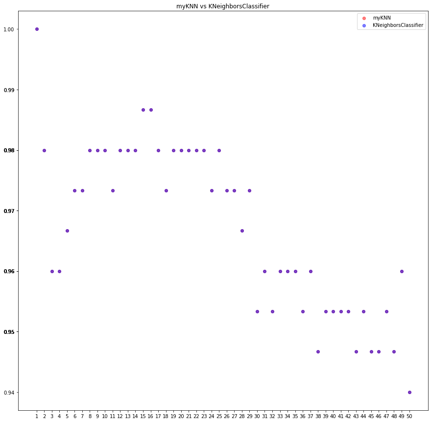

```python
### Code Starts Here ###
plt.figure(figsize=(15,15))
plt.scatter(my_x, my_y,  color="red", alpha=0.5)
plt.scatter(sk_x, sk_y, color="blue",alpha=0.5)
plt.xticks(sk_x)
plt.yticks([round(y, 2) for y in sk_y])
plt.legend(["myKNN", "KNeighborsClassifier"])
plt.title("myKNN vs KNeighborsClassifier")
plt.show()
```

## Results

- As you can see from the chart above, the best `k` is 1.
- Yes, I expected the results to be the same for the same `k` because it is implementing the same algorithm.
- Note that the purple color reflects that the `KNeighborsClassifier` and `myKNN` are reporting the same results

e) (6 pts) Implement Linear Discriminant Analysis (call it `myLDA`) for each pair of the classes and report your results.

```python
### Code Starts Here ###
from matplotlib.colors import ListedColormap

class myLDA:

    def __init__(self, data: ndarray, labels: ndarray):
        """ Initializes the class """
        self.data = data
        self.labels = labels
        self.features = self.data.shape[1]
        self.cls = set(labels)
        self.mean = np.mean(data, axis=0)
        self.results = None

    @property
    def _classes(self) -> dict:
        """ Returns a dictionary of the classes and their values """
        classes = dict()
        for idx, d in enumerate(self.data):
            c = self.labels[idx]
            if classes.get(c) is None:
                classes[c] = np.array([d])
            else:
                classes[c] = np.append(classes[c], [d], axis=0)
        return classes

    @property
    def _class_means(self) -> dict:
        class_means = dict()
        for c,v in self._classes.items():
            class_means[c] = np.mean(v, axis=0)
        return class_means

    @property
    def _within_class_scatter(self) -> ndarray:
        """ Calculates the scatter matrix within a class """
        scatter = np.zeros((self.features, self.features))
        for idx, d in enumerate(self.data):
            c = self.labels[idx]
            diff = (d - self._class_means[c]).reshape((self.features,1))
            s = np.dot(diff, diff.T)
            scatter += s
        return scatter

    @property
    def _btw_class_scatter(self) -> ndarray:
        """ Calculates the scatter matrix between classes """
        scatter = np.zeros((self.features, self.features))
        for k, v in self._class_means.items():
            n = len(self._classes[k])
            mi = self._class_means[k]
            diff = (mi - self.mean).reshape((self.features, 1))
            s = n * np.dot(diff, diff.T)
            scatter += s
        return scatter

    def solve(self) -> ndarray:
        """ Solves the LDA alg """
        inv = np.linalg.inv(self._within_class_scatter)
        vals, vec = np.linalg.eig(np.matmul(inv, self._btw_class_scatter))
        transform = self._W(vals, vec)
        self.results = np.matmul(self.data, transform)
        return self.results

    def plot(self, labels: bool = True) -> None:
        """ Plots the results (slowly) """
        if self.results is None:
            raise ValueError("Equation has not yet been solved")

        if labels:
            color = ('red', 'pink', 'green', 'rocket', 'twilight')
            cmap=ListedColormap(color[:len(self.cls)])

            for idx, c in enumerate(self.cls):
                rows = []
                for jdx in range(len(self.results)):
                    cls = self.labels[jdx]
                    if cls == c:
                        rows.append(jdx)
                plt.scatter(self.results[rows, 0], self.results[rows, 1], color=cmap(idx), label=c)
            plt.legend()

        else:
            plt.scatter(self.results[:,0], self.results[:,1], alpha=0.6, c=self.labels, cmap='prism')

        plt.xlabel('LD1')
        plt.ylabel('LD2')
        plt.show()


    def _W(self, vals: ndarray, vec: ndarray) -> ndarray:
        """ Computes the transformation matrix of shape d (num features) x k (num classes) """
        concat = [(val, vec[:, idx]) for idx, val in enumerate(vals)]
        concat.sort(key=lambda x: x[0], reverse=True)
        cols = tuple(concat[i][1].reshape((self.features, 1)) for i in range(len(self.cls)))
        return np.hstack(cols).real



lda = myLDA(iris.data, iris.target)
X = lda.solve()
```

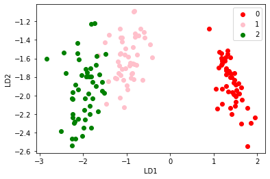

```python
### Code Starts Here ###
lda.plot()
```

## Results

- Linear separation appears to have been a success

### Problem 3 - Logistic Regression (Lecture 4)

(8 pts) In this problem you are going to built a logistic regression, `myLogistic`. The confirmation of the function will be done in HW#3. Here is a brief pseudo code.

a. Initialize the weight and bias.

b. A sigmoid function

c. Forward/backward Propagation functions $𝑧=𝑥_1𝑤_1+\cdots+𝑥_n𝑤_n+𝑏$

d. Updating Parameters Function

e. Prediction Function

f. Main Function - Logistic Regression

g. Calculate the accuracy

```python
class myLogisitic:

    def __init__(self, learning_rate: float, precision: float = 0.0001, cutoff: int = 1000):
        """ Initializes the class """
        self.rate = learning_rate
        self.precision = precision
        self.cutoff = cutoff
        self.loss = list()

    def predict(self, X: ndarray) -> ndarray:
        """ Predicts the class of the input array 0 or 1 """
        X = np.insert(X, 0, 1, axis=1)
        Z = self._Z(X)
        return np.argmax(self._posterior(Z), axis=1)

    def score(self, X: ndarray, y: ndarray) -> float:
        """ Scores how well the KNN predicts """
        correct = 0.0
        predictions = self.predict(X)
        for idx, label in enumerate(predictions):
            correct += int(label == y[idx])
        return correct / len(y)

    def fit(self, X: ndarray, y: ndarray) -> None:
        """ Fits the model to the training data """
        self._bootstrap(X, y)
        for i in range(self.cutoff):
            self._train(X)
            if self.loss[-1] < self.precision:
                break
        self._set_coef()

    def _bootstrap(self, X: ndarray, y: ndarray) -> None:
        """ Initializes a random weight and bias for the input data """
        unique = sorted(np.unique(y))
        cls = len(unique)
        self._rand_coef(X, cls)
        self._one_hot(X, y, unique, cls)

    def _rand_coef(self, X: ndarray, cls: int) -> None:
        weights = np.random.random(cls)
        bias = np.random.random(cls)
        self.coef_matrix = np.insert(
            np.array([weights] * X.shape[1]), 0, bias, axis=0
        )

    def _one_hot(self, X: ndarray, y: ndarray, unique: ndarray, cls: int)-> None:
        """ One hot encodes the targets """
        self.y = np.zeros((X.shape[0], cls))
        for idx, val in enumerate(y):
            cls_idx = unique.index(val)
            self.y[idx][cls_idx] = 1

    def _train(self, X: ndarray) -> None:
        """ Train the model one iteration """
        X = np.insert(X, 0, 1, axis=1)
        Z = self._Z(X)
        posteriors = self._posterior(Z)
        self._descend(X, posteriors)

    def _Z(self, X: ndarray):
        """ Prepares the data for prediction """
        return np.matmul(X, self.coef_matrix)

    def _posterior(self, Z: ndarray) -> ndarray:
        """ Solves the softmax function """
        prob = np.zeros(Z.shape)
        for idx, z in enumerate(Z):
            prob[idx] = np.exp(z) / np.sum(np.exp(z), axis=0)
        return prob

    def _descend(self, X: ndarray, posteriors: ndarray) -> None:
        """ Attempts to descend the error function """
        loss = (-1 / X.shape[0]) * np.sum(self.y * np.log(posteriors))
        cost = (-1 / X.shape[0]) * (X.T.dot((self.y - posteriors)))
        self.loss.append(loss)
        self.coef_matrix -= self.rate * cost

    def _set_coef(self) -> None:
        """ Sets the coefficients based on the weights and bias """
        self.bias = np.mean(self.coef_matrix[0])
        self.weights = np.mean(np.delete(self.coef_matrix, 0, axis=0), axis=0)
        self.coef_ = np.array([self.bias, *self.weights])
```

```python
## Example usage
# log = myLogisitic(0.05)
# log.fit(X, y)  > Fit the model
# log.score(X, y)  > Score the fit
```